# Project log

Pascal Visser

14-9-2021

```r
# Libraries
library(ggplot2)
library(reshape2)
library(dplyr)
library(tidyr)
library(pander)
library(gridExtra)
library(ggrepel)
library(forcats)
library(scales)
```

# 1. Intro

## 1.1 Background

In a research of breast cancer proteomes, 77 breast cancer samples are generated by the NCI/NIH (Clinical Proteomic Tumor Analysis Consortium) generating 3 datasets. A dataset with expression values, a dataset with genes and proteins used by the PAM50 classification system and a dataset with clinical annotations of the patients.

The 77 breast cancer proteome expression values are log2 iTRAQ ratios for each sample. It contains ~12.000 proteins for each individual sample. This database also contains three samples from healthy individuals.

## 1.2 Research question

Is it possible to predict a breast cancer stage, based of the expression data from 77 cancer proteomes?

# 2. Data

As named before, there are three datasets available. For this research, only two the the three will be used. The expression value data and the clinical patient data. There are 105 clinical patient samples and 77 proteome samples. 28 proteomes were cut of the final data due quality issues.

The goal of this research is to see if it is possible to predict the tumor stage based on the protein expression levels of the patients. The clinical database contain useful annotations of the patients such as:

- ER status (estrogen receptors)
- PR status (progesterone receptors)
- HER2 status (HER2 presence)
- Tumor stage (T1 t/m t4)
- Node stage (N0 t/m N3)
- Metastasis (M0 or M1)
- ACCJ status (summary of above annotations)

All these factors can indicate the cancerous state of the patient. In this case, tumor stage is the most important factor. Because the prediction of this tumor stage will be based of the expression level of the samples.

The tumor stage information runs from T1 till T4, with T1 as the least malicious. With the following classification:

- T1: The tumor in the breast is 20 millimetres (mm) or smaller in size at its widest area
- T2: The tumor is larger than 20 mm but not larger than 50 mm.
- T3: The tumor is larger than 50 mm.
- T4: The tumor has grown into the chest wall and/or skin. Metastasis is likely.

The tumor stage is a good indication of how worse the cancer situation is. Thus, a good variable to predict with the expression data.

## 2.1 load data

The data will be loaded from the Data folder in the repository.

```r
# load data
proteomes <- as.data.frame(read.csv(file = 'Data/cancer_proteomes.csv'))
patient_data <- as.data.frame(read.csv(file = "Data/data_patients.csv"))
knitr::kable(head(proteomes[, 1:6]))
```

| RefSeq_accession_number | gene_symbol | gene_name | AO.A12D.01TCGA | C8.A131.01TCGA | AO.A12B.01TCGA |
| --- | --- | --- | --- | --- | --- |
| NP_958782 | PLEC | plectin isoform 1 | 1.096131 | 2.609943 | -0.6598280 |
| NP_958785 | NA | plectin isoform 1g | 1.111370 | 2.650422 | -0.6487422 |
| NP_958786 | PLEC | plectin isoform 1a | 1.111370 | 2.650422 | -0.6542851 |
| NP_000436 | NA | plectin isoform 1c | 1.107561 | 2.646374 | -0.6321133 |
| NP_958781 | NA | plectin isoform 1e | 1.115180 | 2.646374 | -0.6404277 |
| NP_958780 | PLEC | plectin isoform 1f | 1.107561 | 2.646374 | -0.6542851 |

The proteomes file contain 86 columns: 3 columns with gene information, 80 columns of expression data with TCGA.ID (with 3 duplicates) and 3 columns of expression data of healthy persons.

Also the clinical patient data is loaded in. Containing the tumor stage annotation that will be used.

```r
knitr::kable(head(patient_data[, 1:6]))
```

| Complete.TCGA.ID | Gender | Age.at.Initial.Pathologic.Diagnosis | ER.Status | PR.Status | HER2.Final.Status |
| --- | --- | --- | --- | --- | --- |
| TCGA-A2-A0T2 | FEMALE | 66 | Negative | Negative | Negative |
| TCGA-A2-A0CM | FEMALE | 40 | Negative | Negative | Negative |
| TCGA-BH-A18V | FEMALE | 48 | Negative | Negative | Negative |
| TCGA-BH-A18Q | FEMALE | 56 | Negative | Negative | Negative |
| TCGA-BH-A0E0 | FEMALE | 38 | Negative | Negative | Negative |
| TCGA-A7-A0CE | FEMALE | 57 | Negative | Negative | Negative |

## 2.2 Transform data

To make the proteomes file more workable, the column name with the TCGA.ID will become the row name. Also the first 3 and the last 3 row will be excluded. The first 3 columns contains RefSeq number, gene_symbol and gene name. The RefSeq number will be saved as column name. The last 3 columns contains expression data of healthy people with no ID match to the patients, so this information is not needed.

```r
# Transform colnames and rownames

# Save the RefSeq numbers
nm <- proteomes$RefSeq_accession_number

# Exclude col 1-3 and 84-86
proteomes <- as.data.frame(t(proteomes[,4:83]))
colnames(proteomes) <- nm

# Bind the colnames to the rows
proteomes <- cbind(rownames(proteomes), data.frame(proteomes, row.names=NULL))
colnames(proteomes)[1] <- "Complete.TCGA.ID"
```

To match the ID of the clinical patient data, the ID of the proteomes data will be transformed. Also the 3 duplicates will be removed.

```r
# Make function to transform TGCA ID
clinical.id <- function(proteome.id) {
  x = substr(proteome.id, 4, 7)
  y = substr(proteome.id, 0, 2)
  paste("TCGA",y,x,sep="-")
}

#Sapply to id column in proteomes
proteomes$Complete.TCGA.ID <- sapply(proteomes$Complete.TCGA.ID, clinical.id)
proteomes_new <- proteomes

# Remove duplicates
proteomes_new <- proteomes_new[!duplicated(proteomes_new$Complete.TCGA.ID), ]
knitr::kable(head(proteomes_new[, 1:6]))
```

| Complete.TCGA.ID | NP_958782 | NP_958785 | NP_958786 | NP_000436 | NP_958781 |
| --- | --- | --- | --- | --- | --- |
| TCGA-AO-A12D | 1.0961312 | 1.1113704 | 1.1113704 | 1.1075606 | 1.1151802 |
| TCGA-C8-A131 | 2.6099430 | 2.6504218 | 2.6504218 | 2.6463739 | 2.6463739 |
| TCGA-AO-A12B | -0.6598280 | -0.6487422 | -0.6542851 | -0.6321133 | -0.6404277 |
| TCGA-BH-A18Q | 0.1953407 | 0.2154129 | 0.2154129 | 0.2053768 | 0.2154129 |
| TCGA-C8-A130 | -0.4940596 | -0.5038992 | -0.5006193 | -0.5104589 | -0.5038992 |
| TCGA-C8-A138 | 2.7650807 | 2.7797092 | 2.7797092 | 2.7979949 | 2.7870235 |

Now the proteomes file has the ID in the first column. Then the next 12.554 columns are the expression data of the corresponding protein.

## 2.3 Adding tumor data

Next the tumor stage annotation for the patient_data must merge into the proteomes data frame.

```r
# Join data frames by ID
proteomes_complete <- merge(patient_data, proteomes_new, BY = 'Complete.TCGA.ID')

# Drop unwanted columns
proteomes_complete <- proteomes_complete[-c(2:6,8:30)]

# Rename column
colnames(proteomes_complete)[2] <- 'Tumor_Stage'
knitr::kable(head(proteomes_complete[, 1:6]))
```

| Complete.TCGA.ID | Tumor_Stage | NP_958782 | NP_958785 | NP_958786 | NP_000436 |
| --- | --- | --- | --- | --- | --- |
| TCGA-A2-A0CM | T2 | 0.6834035 | 0.6944241 | 0.6980976 | 0.6870771 |
| TCGA-A2-A0D2 | T2 | 0.1074909 | 0.1041645 | 0.1074909 | 0.0975117 |
| TCGA-A2-A0EQ | T2 | -0.9126703 | -0.9279787 | -0.9279787 | -0.9318058 |
| TCGA-A2-A0EV | T1 | 0.4529859 | 0.4725901 | 0.4725901 | 0.4585871 |
| TCGA-A2-A0EX | T3 | 1.1851082 | 1.1926120 | 1.1888601 | 1.1851082 |
| TCGA-A2-A0EY | T2 | 1.1748810 | 1.1832088 | 1.1832088 | 1.1748810 |

Now the Tumor stage annotation is added to the data frame.

## 2.4 Wide to long format

For many functions R expects data to be in a long format, rather than a wide format. Thus the dataset will be converted to a long format

```r
# wide to long format with reshape2 package
pro_long <- melt(proteomes_complete, id.vars = c("Complete.TCGA.ID", "Tumor_Stage"),
variable.name = "Protein_RefSeq")
head(pro_long)
```

|  | Complete.TCGA.ID | Tumor_Stage | Protein_RefSeq | value |
| --- | --- | --- | --- | --- |
| 1 | TCGA-A2-A0CM | T2 | NP_958782 | 0.6834035 |
| 2 | TCGA-A2-A0D2 | T2 | NP_958782 | 0.1074909 |
| 3 | TCGA-A2-A0EQ | T2 | NP_958782 | -0.9126703 |
| 4 | TCGA-A2-A0EV | T1 | NP_958782 | 0.4529859 |
| 5 | TCGA-A2-A0EX | T3 | NP_958782 | 1.1851082 |
| 6 | TCGA-A2-A0EY | T2 | NP_958782 | 1.1748810 |

Now the data is in a workable long format, that is better to be handled by R. This will complete the data formatting.

# 3. Exploratory data analysis

For a good understanding of the data, is a EDA necessary. EDA stands for exploratory data analysis. In this part of the journal, the formatted data is visualised and explored. By neat and annotated tables and figures, the data will be much more clear and shows new insights.

- Summary
- Missing data
- Distribution
- Tumor stage distribution

## 3.1 Summary

First, let’s look at a summary of all the expression values from the dataset:

```r
# Summary all
pander(summary(pro_long$value), caption = 'Total')
```

Total The median and mean of all the expression values are negative, which means that most proteins are synthesised less. There is a high maximum and a low minimum. These are probably outliers. Also there are 100622 NA’s out of 966,581 expressions values, which equals to 10,41%. Next there will be a summary per Tumor stage to see if there are notable differences.

[output not shown]

```r
# apply a summary per Tumor stage
pander(tapply(pro_long$value, pro_long$Tumor_Stage, summary))
```

- **T1**:

  | Min. | 1st Qu. | Median | Mean | 3rd Qu. | Max. | NA’s |
  | --- | --- | --- | --- | --- | --- | --- |
  | -19.63 | -0.9878 | -0.1006 | -0.2717 | 0.6981 | 17.62 | 13403 |

- **T2**:

  | Min. | 1st Qu. | Median | Mean | 3rd Qu. | Max. | NA’s |
  | --- | --- | --- | --- | --- | --- | --- |
  | -24.55 | -0.9046 | -0.06929 | -0.1869 | 0.7019 | 15.44 | 66912 |

- **T3**:

  | Min. | 1st Qu. | Median | Mean | 3rd Qu. | Max. | NA’s |
  | --- | --- | --- | --- | --- | --- | --- |
  | -22.68 | -0.9804 | -0.09064 | -0.3098 | 0.6694 | 11.77 | 13174 |

- **T4**:

  | Min. | 1st Qu. | Median | Mean | 3rd Qu. | Max. | NA’s |
  | --- | --- | --- | --- | --- | --- | --- |
  | -16.36 | -0.8491 | -0.03962 | -0.08701 | 0.7275 | 11.93 | 7133 |

Same story here, negative means and medians, couple of outliers at the max. and min. No noticeable differences.

## 3.2 Missing data

With all big datasets, it is never 100% complete. Also in this dataset, multiple NA’s are present. But how much? And which proteins has the most NA’s?

```r
#total na's in dataset
tot.na <- sum(is.na(pro_long))
cat("Total number of NA's in dataset: ", tot.na)
```

```
## Total number of NA's in dataset:  100622
```

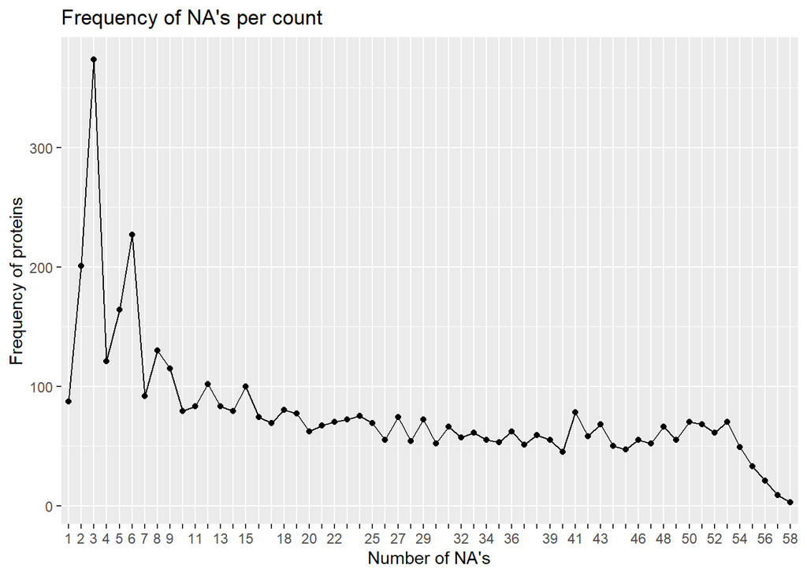

```r
# calculate na's per protein
na_per_protein <- aggregate(value ~ Protein_RefSeq, data=pro_long, function(x) {sum(is.na(x))}, na.action = NULL)
nas <- as.data.frame(table(na_per_protein$value[na_per_protein$value>=1]))


# plot
ggplot(nas, aes(Var1, Freq, group = 1)) + geom_line() + geom_point() +
labs(x = "Number of NA's", y = 'Frequency of proteins', title = "Frequency of NA's per count") +
scale_x_discrete(guide = guide_axis(check.overlap = TRUE))
```

Out of the total 12553 protein in the dataset, 8017 proteins contain zero Na’s, which means that 4536 protein have one or more NA’s. In the graph is to see that low to medium counts of NA’s are no uncommon.

## 3.3 Distribution

The distribution shows the spread of the data. The distribution can be shown by expression value and per tumor stage.

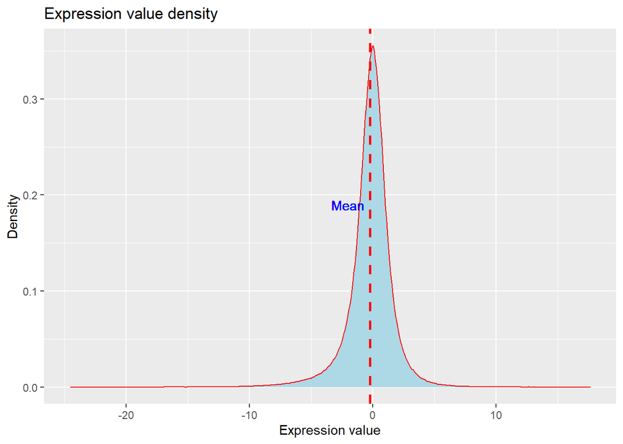

```r
# plot density expression value
plot1 <- ggplot(pro_long, aes(x = value)) +
         geom_density(color = 'red', fill = 'lightblue') +
         geom_vline(aes(xintercept=mean(value, na.rm=T)),color="red", linetype="dashed", size=1) +
         geom_text(aes(x=-2, label="\nMean", y=0.2), colour="blue", angle=0, text=element_text(size=11)) +
         labs(x = 'Expression value', y = 'Density', title = 'Expression value density')

# plot density by tumor stage
plot2 <- ggplot(pro_long, aes(x = value, group = Tumor_Stage, fill = Tumor_Stage)) +
         geom_density(adjust=1.5, alpha = .4) +
         labs(x = 'Expression value', y = 'Density', title = 'Expression density by tumor stage')

plot1
```

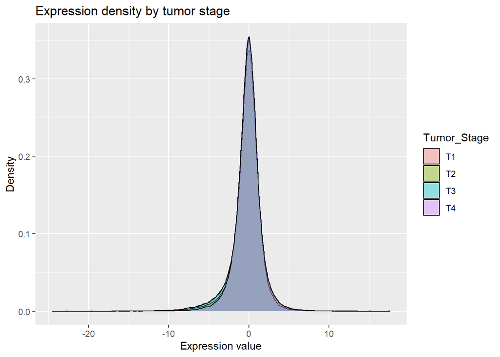

```r
plot2
```

The above distribution graphs shows very little variation in the data. In the general expression value plot, the peak lay around the 0, with a little more distribution towards the negative.

In the tumor stage density, the 4 stage overlap in the plot. But the difference is so little, that the overlap barely can be seen.

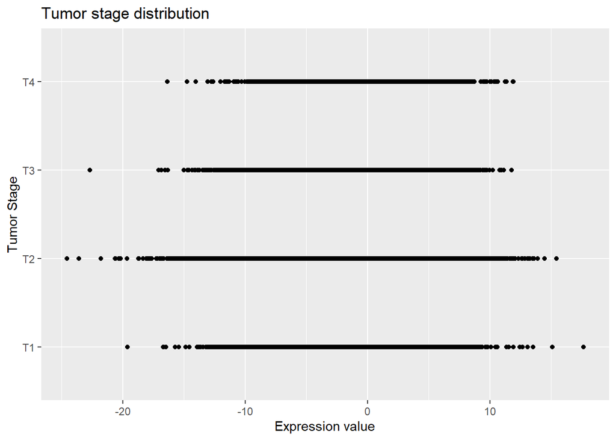

```r
ggplot(pro_long, aes(x = value, y = Tumor_Stage)) +
geom_point(na.rm = T) + labs(x = 'Expression value', y = 'Tumor Stage', title = 'Tumor stage distribution')
```

Also, the plot above shows the distribution by tumor group as a scatterplot. Here the outliers can better be identified, but no real difference between the groups.

## 3.4 Tumor stage distribution

Each of the 77 patient is categorised in a tumor group, based of the tumor size and malicious state. But how many patient are in each stage? and how is this divided?

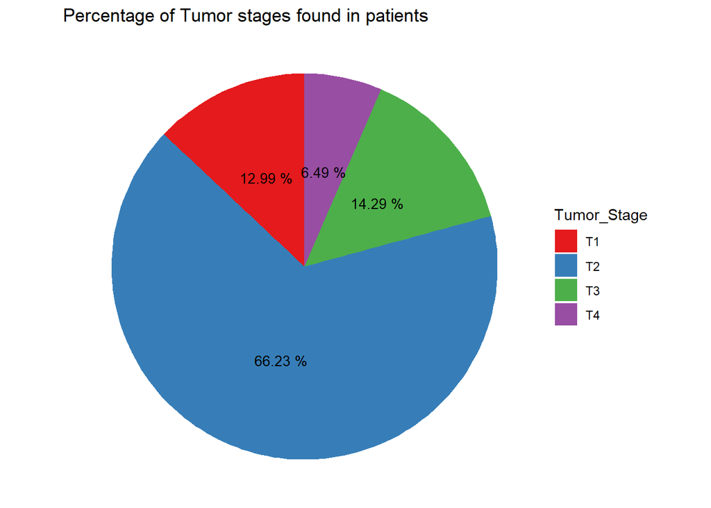

```r
# count frequency of tumor groups
stage_count <- proteomes_complete %>%
            select(Tumor_Stage) %>%
            group_by(Tumor_Stage) %>%
            count()

prtage <- paste(round(100*stage_count$n/sum(stage_count$n), 2), "%")

# plot pie chart
ggplot(stage_count, aes(x = '', y = n, fill = Tumor_Stage)) + geom_bar(stat = 'identity', width = 2) + coord_polar('y', start = 0) +
theme_void() +  geom_text(aes(label = prtage), position = position_stack(vjust = 0.50), size = 3.5) + scale_fill_brewer(palette="Set1") + labs(title = 'Percentage of Tumor stages found in patients')
```

Tumor stage T2 is obvious the most common stage. 66% of the patients are in this stage. T1 and T3 share the about the same percentage. T4 is the rare group , with only 6,5% of the patients. Patients in stage T4 have a high mortality rate, so they die early. that’s why the T4 percentage probably is so small.

For T1, the tumor is 20 millimetres or smaller in size. thus it is difficult to detect. By stage T2 the tumor is a must more detectable size. therefore that’s why T2 is probably more common.